# TU060 - Math 9102 – PSI - Portfolio - Explore

Joseph O’Carroll

28/11/2020

# Introduction:

The purpose of this section is to address all required concepts comprehensively and demonstrate coherent understanding of the statistical analysis exploration phase, as covered during the TU060 MATH9102 Module.

In the preparation phase we came up with a question that needed to be answered and generated a number of hypotheses that could be tested through statistical analysis. The next step is to collect data to see whether the theory is accurate. To do this one or more variables needs to be identified and appropriate statistical measurements need to be calculated.

- Selection, with justification, of the appropriate variables to investigate the theory identified in the preparation phase.
- Description of statistical measures associated with variables under consideration.
- Selection of appropriate assessments/tests to investigate issues with statistical measures.
- Interpretation of findings and generation appropriate conclusions.

As part of this portfolio assignment, all the scope of variables along with their measurements has already been provided, as such understanding is illustrated through application to the real-world data Portuguese Secondary School Student Performance dataset provided.

### Citation:

- Cortez and A. Silva. Using Data Mining to Predict Secondary School Student Performance. In A. Brito and J. Teixeira Eds., Proceedings of 5th FUture BUsiness TEChnology Conference (FUBUTEC 2008) pp. 5-12, Porto, Portugal, April, 2008, EUROSIS, ISBN 978-9077381-39-7. (https://repositorium.sdum.uminho.pt/bitstream/1822/8024/1/student.pdf) Data:

### Import dataset

```r
############
# PART: Import data
############
# Dateset 1 : Import sperformance-dataset
tbl_sperf_all <- read.csv('sperformance-dataset.csv', header = TRUE)
names(tbl_sperf_all)[1] <- 'School' # Fix issue with the name of first field.

# Dateset 2 : Import sperformance-dataset variable description
tbl_sperf_description_all <- read.csv('TU060_MATH9102_Student_variables_description.csv',
                                      header = TRUE)
```

# Hypothesis testing - Correlation:

A general description of all variables in the dataset was provided as part of the preparation phase. Our goal is to accurately summarise and describe what’s happening in the data but before we can build a predictive model we need to work out what predictor variables to include in our hypothesis testing. We cannot include all variables in our tests as variables as it would be difficult to see which variables truly influence our outcome variables. So our starting point of the exploration phase is to answer the question, what type of covariation occurs between variables? This will provide the justification for variable selection in hypothesis testing. The first steps are to:

- Isolate whether variables have a relationship or whether there is a differential effect for different groups.
- Provide statistical evidence that justifies us including these variables as predictors in a predictive model.
- Investigate if differential effects exist for different groups.

In the general linear statistical model the hypothesis is that the concepts of interest, as measured by their variable, are related to each other in such a way that the relationship is linear. This means that when one variable increases the other increases or decreases proportionally or there are patterns which are similar within different groups. Using the general linear statistical model, we are trying to use the equation of a line as our model of the pattern in the relationship between the two variables (Bi variant correlation). For assessing covariant correlation, the questions we need to answer for each pair of variables are:

- Can the relationship between the two variables be modeled as a straight line?
- What is the direction of the covariation (positive or negative)?
- What is the strength of the covariation (weak, moderate, or strong)?
- What is the statistical significances (likelihood the relationship we observe is occurring due to chance)

## Correlation testing - Past Performance and Future Performance

From the preparation phase we had the Hypothesis;

> Hypothesis; students who perform well during interim assessment in subjects will perform better overall.

In terms of testing for correlation, the null hypothesis Is that there is no relationship between past performance and future performance. The alternative hypothesis is that there is a positive relationship between these two variables. This is considered a one tailed hypothesis.

For each subject we have we have two potential predictor variables which are Grade 1 and 2, and one outcome variable, grade 3. As such we will conduct a total of four tests for correlation.

### Step 1 Check for Normality of the Variables

Pearson Correlation requires variables values are normally distributed. We validate that by generating summary statistics and histograms and for each of the variables and checking for normality. To illustrate the concept of accessing normality we have selected the grades for Portuguese and Maths form the sample dataset. We have completed the following steps:

- Generated plots ** Histogram with normal curve showing ** Q-Q Plot
- Generated Summary statistics
- Reviewed the statistical measures and plots to see how far awy from normal the sample data is.
- Report the correct statistics for this data based on an assessment of normality.

Summary statistics for Performance (not cleaned)

|  | vars | n | mean | sd | median | trimmed | mad | min | max | range | skew | kurtosis | se | IQR |
| --- | --- | --- | --- | --- | --- | --- | --- | --- | --- | --- | --- | --- | --- | --- |
| mG1 | 1 | 382 | 10.86126 | 3.349167 | 10.5 | 10.74510 | 3.7065 | 3 | 19 | 16 | 0.2741912 | -0.7061137 | 0.1713583 | 5.00 |
| mG2 | 2 | 382 | 10.71204 | 3.832560 | 11.0 | 10.83007 | 2.9652 | 0 | 19 | 19 | -0.3970490 | 0.4666241 | 0.1960908 | 4.75 |
| mG3 | 3 | 382 | 10.38743 | 4.687242 | 11.0 | 10.81373 | 4.4478 | 0 | 20 | 20 | -0.7003219 | 0.2415275 | 0.2398202 | 6.00 |
| pG1 | 4 | 382 | 12.11257 | 2.556531 | 12.0 | 12.09150 | 2.9652 | 0 | 19 | 19 | -0.1523548 | 0.6986985 | 0.1308035 | 4.00 |
| pG2 | 5 | 382 | 12.23822 | 2.468341 | 12.0 | 12.15359 | 2.9652 | 5 | 19 | 14 | 0.2368869 | -0.2038155 | 0.1262913 | 3.00 |
| pG3 | 6 | 382 | 12.51571 | 2.945438 | 13.0 | 12.62092 | 2.9652 | 0 | 19 | 19 | -0.9891237 | 3.3902597 | 0.1507017 | 3.00 |

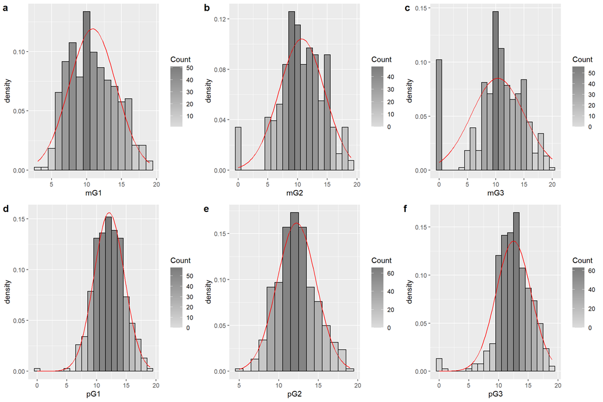

Any Outliers, Skew, or kurtosis needs to be investigated and explained. We can see above that there appears to be an issue with no grades being reported for some students. Not all student records contain grades 1 through 3. Some records have grades 1 and 2, but no final grade, others are missing grades 1 or 2 but have a final grade.

The reference paper highlighted that student performance is being manually recorded using a paper based filing system and this might be a clerical error. For illustration purposes we will assume a zero grade is not possible and represents missing data. We will then regenerate our summary statistics and graphs on a cleaned dataset.

```r
############
# PART: Normality
############
# For illsutration just looking at Math.
tbl_sperf_numerical_measurements <- tbl_sperf_all %>%
  select(contains('mG'), contains('pG')) %>%
  filter(mG1 != 0, mG2 != 0, mG3 != 0, pG1 != 0, pG2 != 0, pG3 != 0) # Filtering records with missing data.

tbl_sperf_numerical_stats <- tbl_sperf_numerical_measurements %>%
  psych::describe(omit = TRUE, IQR = TRUE)

#-------- Iterate through eact variable -------#
#Generate regular summary statistics - not as nice as psych package but gives p value
st <- pastecs::stat.desc(tbl_sperf_numerical_measurements, basic = F)
tbl_sperf_numerical_stats_2 <- st %>% transpose()
colnames(tbl_sperf_numerical_stats_2) <- rownames(st)
rownames(tbl_sperf_numerical_stats_2) <- colnames(st)

# Initialise vectors
std_skew <- list()
std_kurt <- list()
gt_196 <- list()
gt_329 <- list()
variable_count <- nrow(tbl_sperf_numerical_stats_2)

# Iterate through varibles
for (n in 1:variable_count) {
  variable <- row.names.data.frame(tbl_sperf_numerical_stats_2)[n]

  tpskew               <- semTools::skew(tbl_sperf_numerical_measurements[[variable]])
  tpkurt               <- semTools::kurtosis(tbl_sperf_numerical_measurements[[variable]])
  std_skew[[variable]] <- tpskew[1] / tpskew[2]
  std_kurt[[variable]] <- tpkurt[1] / tpkurt[2]
  z_score              <- abs(scale(tbl_sperf_numerical_measurements[[variable]]))
  gt_196[[variable]]   <- FSA::perc(as.numeric(z_score), 1.96, "gt") # 95% within +/- 1.96
  gt_329[[variable]]   <- FSA::perc(as.numeric(z_score), 3.29, "gt") # 99.7% within +- 3.29 for larger distributions

}

tbl_sperf_numerical_stats_2$std_skew <- std_skew
tbl_sperf_numerical_stats_2$std_kurt <- std_kurt
tbl_sperf_numerical_stats_2$gt_2sd <- gt_196
tbl_sperf_numerical_stats_2$gt_3sd <- gt_329

# Pretty print
tbl_sperf_numerical_stats_2 %>%
  kbl(caption = "Summary statistics for Performance (zero scores removed)") %>%
  kable_styling(bootstrap_options = c("striped", "hover"))
```

Summary statistics for Performance (zero scores removed)

|  | median | mean | SE.mean | CI.mean.0.95 | var | std.dev | coef.var | std_skew | std_kurt | gt_2sd | gt_3sd |
| --- | --- | --- | --- | --- | --- | --- | --- | --- | --- | --- | --- |
| mG1 | 11 | 11.28614 | 0.1758996 | 0.3459959 | 10.488890 | 3.238656 | 0.2869588 | 1.646218 | -2.505487 | 3.539823 | 0 |
| mG2 | 11 | 11.43953 | 0.1730551 | 0.3404007 | 10.152397 | 3.186283 | 0.2785327 | 1.551482 | -2.093272 | 7.079646 | 0 |
| mG3 | 11 | 11.61947 | 0.1769549 | 0.3480716 | 10.615123 | 3.258086 | 0.2803989 | 1.646578 | -1.701956 | 3.834808 | 0 |
| pG1 | 12 | 12.36578 | 0.1311432 | 0.2579596 | 5.830305 | 2.414602 | 0.1952648 | 1.024839 | -1.390545 | 3.539823 | 0 |
| pG2 | 12 | 12.47493 | 0.1302716 | 0.2562453 | 5.753068 | 2.398555 | 0.1922701 | 2.509813 | -1.315284 | 3.244838 | 0 |
| pG3 | 13 | 12.82301 | 0.1402359 | 0.2758450 | 6.666806 | 2.582016 | 0.2013580 | -1.47584 | 3.064222 | 5.014749 | 0.2949853 |

```
##       median         mean      SE.mean CI.mean.0.95          var      std.dev
##   13.0000000   12.8230088    0.1402359    0.2758450    6.6668063    2.5820159
##     coef.var
##    0.2013580
```

```
## skew (g1)
##  -1.47584
```

```
## Excess Kur (g2)
##        3.064222
```

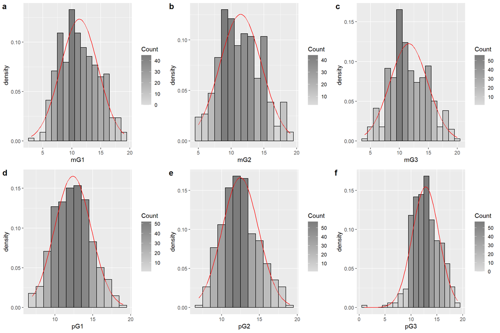

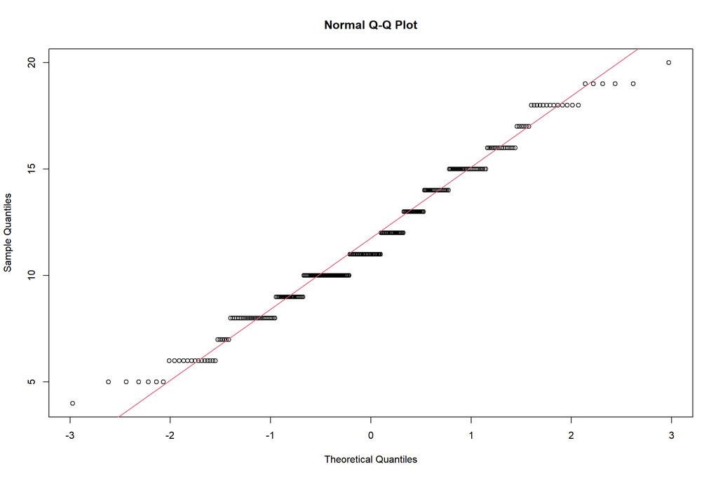

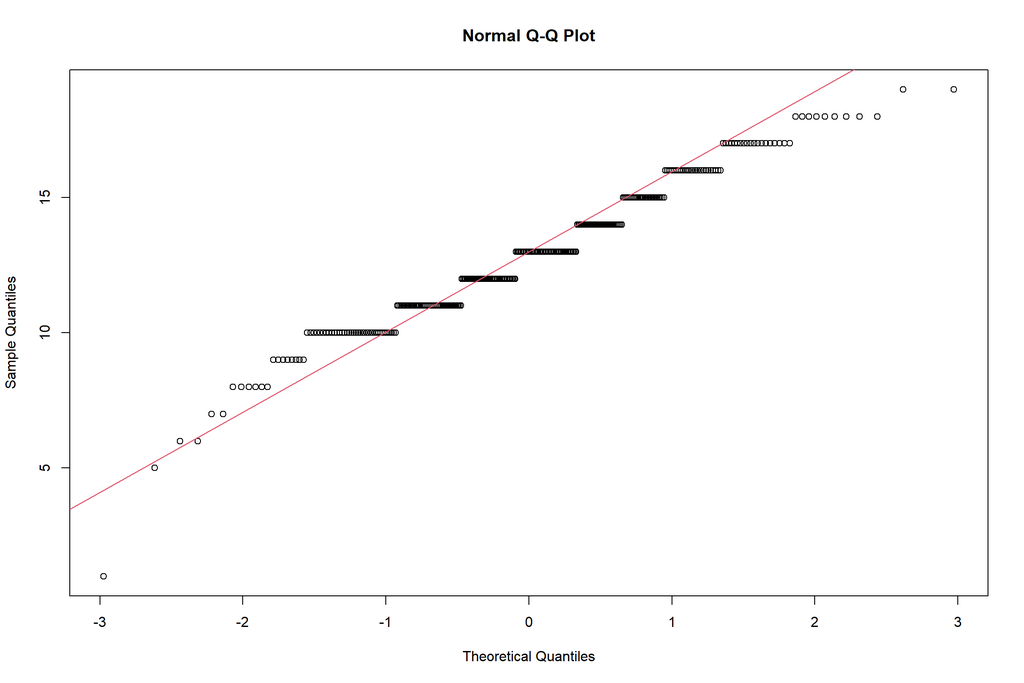

#### Assessing Portuguese and Maths final grade Distribution – Does they fit the normal distribution

To illustrate the concept of assessung normality we selected the final grades for Portuguese and Maths form the sample dataset. The Normal Quantile Plot (Q-Q Plot) showed the data was approximately normal with observations lying on teh reference line. Standardised scores (value/std.error) for skewness between +/-2 (1.96 rounded) are considered acceptable in order to prove normal distribution. Skewness for pG2 not acceptable so we need to look into this further. Need to explore outliers, how many of them there are or whether we can transform it to become more normal.

In terms of quantifying how far away from normal our data is, we generated standarised z scores from variable measures and calculated the percentage of the standardised scores that are outside an acceptable range. pG3 exceeded our acceptable range for values outside the 99.7% confidence interval. mG2 and pG3 exceeded the 95% confidence interval but as our number of examples exceeds 80 this is OK. pG2 is within our acceptable range, so we can assume the excess skewness is not an issue for accepting normality of this variable and pG3 was within out acceptable range for standardised skew.

Based on this assessment, all performance variables can be treated as normally distributed once missing data outliers have been removed.

### Step 2 Check for Linearity of the Co Variance

The goal is to model the covariance of variables using the equation of a line. Pearson Correlation requires there to be a linear relationship between the two variables and we validate that through inspection of a scatterplot which should resemble a straight line and not a curved line. Below we graph the predictor/explanatory variable on the X axis and response/outcome variable on the Y axis.

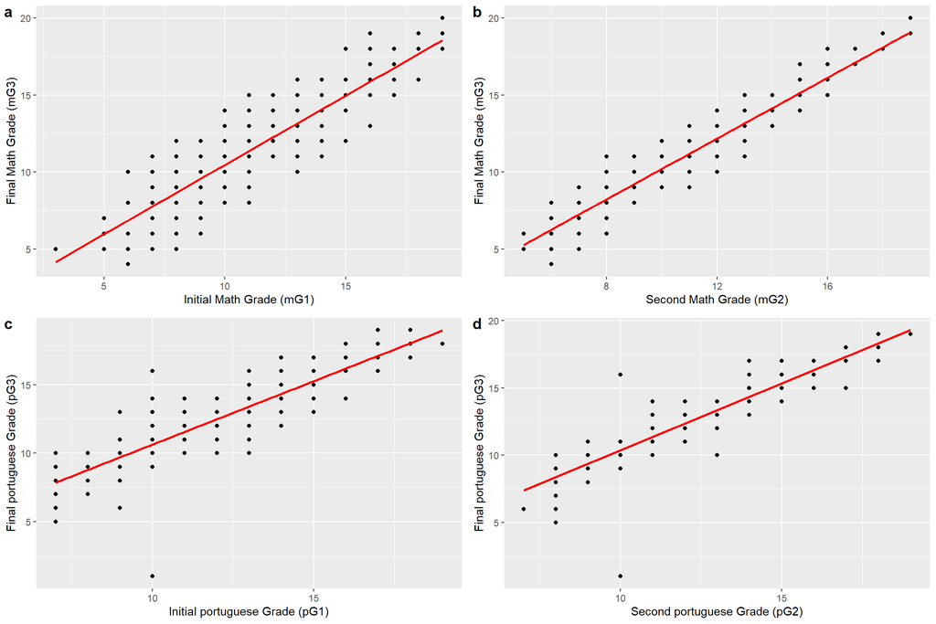

```r
############
# PART: Visualisation
############

# Initial Math Grade (mG1)
plots <- list()
gs <- tbl_sperf_numerical_measurements %>% ggplot2::ggplot(aes(x = mG1, y = mG3))
gs <- gs +
  geom_point() +
  geom_smooth(method = "lm", colour = "Red", se = F) +
  labs(x = "Initial Math Grade (mG1)", y = "Final Math Grade (mG3)")
plots[["mG1 <-> mG3"]] <- gs

# Second Math Grade (mG2)
gs <- tbl_sperf_numerical_measurements %>% ggplot2::ggplot(aes(x = mG2, y = mG3))
gs <- gs +
  geom_point() +
  geom_smooth(method = "lm", colour = "Red", se = F) +
  labs(x = "Second Math Grade (mG2)", y = "Final Math Grade (mG3)")
plots[["mG2 <-> mG3"]] <- gs

gs <- tbl_sperf_numerical_measurements %>% ggplot2::ggplot(aes(x = pG1, y = pG3))
gs <- gs +
  geom_point() +
  geom_smooth(method = "lm", colour = "Red", se = F) +
  labs(x = "Initial portuguese Grade (pG1)", y = "Final portuguese Grade (pG3)")
plots[["pG1 <-> pG3"]] <- gs

# Second Math Grade (mG2)
gs <- tbl_sperf_numerical_measurements %>% ggplot2::ggplot(aes(x = pG2, y = pG3))
gs <- gs +
  geom_point() +
  geom_smooth(method = "lm", colour = "Red", se = F) +
  labs(x = "Second portuguese Grade (pG2)", y = "Final portuguese Grade (pG3)")

plots[["pG2 <-> pG3 "]] <- gs


plot_grid(plotlist = plots,
          labels   = "auto", ncol = 2
)
```

```r
############
# PART: Linearity of Co-variant relationship
############
#Pearson Correlation
### mG1 correlated to mG3
tbl_correlation_stats <- stats::cor.test(tbl_sperf_numerical_measurements$mG1, tbl_sperf_numerical_measurements$mG3, method = 'pearson')
show(tbl_correlation_stats)
```

```
##
##  Pearson's product-moment correlation
##
## data:  tbl_sperf_numerical_measurements$mG1 and tbl_sperf_numerical_measurements$mG3
## t = 36.943, df = 337, p-value < 2.2e-16
## alternative hypothesis: true correlation is not equal to 0
## 95 percent confidence interval:
##  0.8722090 0.9147845
## sample estimates:
##       cor
## 0.8955274
```

```r
### mG2 correlated to mG3
tbl_correlation_stats <- stats::cor.test(tbl_sperf_numerical_measurements$mG2, tbl_sperf_numerical_measurements$mG3, method = 'pearson')
show(tbl_correlation_stats)
```

```
##
##  Pearson's product-moment correlation
##
## data:  tbl_sperf_numerical_measurements$mG2 and tbl_sperf_numerical_measurements$mG3
## t = 68.944, df = 337, p-value < 2.2e-16
## alternative hypothesis: true correlation is not equal to 0
## 95 percent confidence interval:
##  0.9584693 0.9727246
## sample estimates:
##       cor
## 0.9663306
```

```r
### pG1 correlated to pG3
tbl_correlation_stats <- stats::cor.test(tbl_sperf_numerical_measurements$pG1, tbl_sperf_numerical_measurements$pG3, method = 'pearson')
show(tbl_correlation_stats)
```

```
##
##  Pearson's product-moment correlation
##
## data:  tbl_sperf_numerical_measurements$pG1 and tbl_sperf_numerical_measurements$pG3
## t = 31.866, df = 337, p-value < 2.2e-16
## alternative hypothesis: true correlation is not equal to 0
## 95 percent confidence interval:
##  0.8372549 0.8907966
## sample estimates:
##       cor
## 0.8664967
```

```r
### pG2 correlated to pG3
tbl_correlation_stats <- stats::cor.test(tbl_sperf_numerical_measurements$pG2, tbl_sperf_numerical_measurements$pG3, method = 'pearson')
show(tbl_correlation_stats)
```

```
##
##  Pearson's product-moment correlation
##
## data:  tbl_sperf_numerical_measurements$pG2 and tbl_sperf_numerical_measurements$pG3
## t = 43.489, df = 337, p-value < 2.2e-16
## alternative hypothesis: true correlation is not equal to 0
## 95 percent confidence interval:
##  0.9034209 0.9359535
## sample estimates:
##       cor
## 0.9212835
```

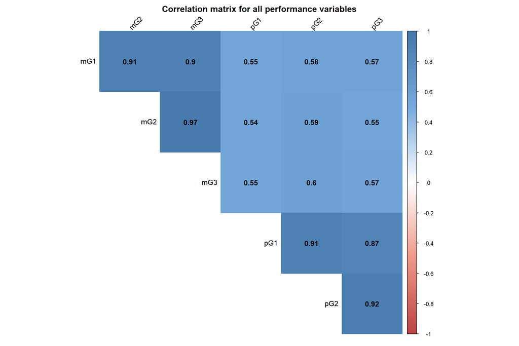